# doAzureParallel - parallel computing in the cloud

Alison Poulston

14th May 2019

## Embarrassingly Parallel

- Little or *no dependency* or need for communication between those parallel tasks, or for results between them.
- Different from *distributed computing problems* that need communication between tasks, especially communication of intermediate results.
- The opposite of embarrassingly parallel problems are inherently *serial problems*, which cannot be parallelized at all.

## Easiest way to spot this

- For loop where **only i** features, not for example *i-1* and *i*.

## Point of this talk

- You have an embarrassingly parallel problem that you want to speed up.
- You don’t have the time/temperament to get over the learning curve of setting batch jobs up yourself or using VMs.
- Cloud computing can help with a lot of different compute-time issues, but today we’re focusing on a very limited scenario because it’s going to only take 10 mins to learn how to implement and get using it.
- You get your results back instantly and can go on to using them in the rest of your rscript without hassle.

## Packages

- Before we go to the cloud, let’s look at parallelising on our own machine.

```r
library(doParallel)
```

## A (slow) birthday problem

```r
pbirthdaysim <- function(n, nsims = 100000, feb29 = TRUE) {
 # Using nsims simulations, estimate the probability
 # that a room of n people includes a shared birthday

 if(!feb29){
   bdays <- 1:365
   probs <- rep(1/365, 365)
 } else { # Feb 29 is day 366, sample other days 4 times as often
   bdays <- 1:366
   probs <- c(rep(4,365),1)
   probs <- probs / sum(probs)
 }

 anydup <- function(ignored)
  # simulate n birthdays, return TRUE if there's a duplicate
  any(duplicated(
   sample(bdays, n, prob=probs, replace=TRUE)))

 sum(sapply(seq(nsims), anydup)) / nsims
}
```

## `Foreach` implementation

Re-writing a for-loop as a sequential `foreach` loop:

```r
x <- foreach(i = 1:3) %do% sqrt(i)
x
```

```
## [[1]]
## [1] 1
##
## [[2]]
## [1] 1.414214
##
## [[3]]
## [1] 1.732051
```

With `foreach` we can easily include more than one iterator:

```r
x <- foreach(a = 1:3, b = 4:6) %do% {
  a + b
}
x
```

```
## [[1]]
## [1] 5
##
## [[2]]
## [1] 7
##
## [[3]]
## [1] 9
```

We can control how we want our results to be combined and stored.

- Specifying ‘c’ is useful for concatenating the results into a vector. - The values ‘cbind’ and ‘rbind’ can combine vectors into a matrix. - The values ‘+’ and ’*’ can be used to process numeric data.

```r
x <- foreach(i = 1:3, .combine = 'c') %do% sqrt(i)
x
```

```
## [1] 1.000000 1.414214 1.732051
```

The values for the iteration variables don’t have to be specified with only vectors or lists.

- Can be specified with an iterator, many of which come with the iterators package. - A vector isn’t itself an iterator, but the foreach function automatically creates an iterator from a vector, list, matrix, or data frame, for example.

```r
a <- iter(1:3)
nextElem(a)
```

```
## [1] 1
```

```r
nextElem(a)
```

```
## [1] 2
```

```r
nextElem(a)
```

```
## [1] 3
```

```r
a <- matrix(runif(20), nrow = 10)
x <- foreach(i = iter(a, by = 'row'), .combine = 'c') %do% sum(i)
x
```

```
##  [1] 1.3529171 1.3032601 1.0605599 0.8805776 0.7443658 1.4609988 1.5527433
##  [8] 0.2904492 1.5239089 1.0923302
```

```r
a <- data.frame(x = runif(100), y = factor(sample(c("A", "B"), 100, replace = T)))
head(a)
```

```
##           x y
## 1 0.4647973 B
## 2 0.3477218 A
## 3 0.7719180 A
## 4 0.8469447 A
## 5 0.7771545 B
## 6 0.2900870 B
```

```r
b <- isplit(a$x, a$y)
x <- foreach(i = b, .combine = 'c') %do% sum(i$value)
x
```

```
## [1] 31.9660 19.6415
```

## Birthday problem in sequence

Regular for-loop syntax would be:

```
bdayp <- rep(NA, 100)
for (n in 1:100) {
  bdayp[n] <- pbirthdaysim(n)
}
```

In `foreach` it would be:

```r
stime <- system.time({
  bdayp <- foreach(n = 1:100, .combine = 'c') %do% pbirthdaysim(n)
})

stime
```

```
##    user  system elapsed
## 304.409   7.872 315.256
```

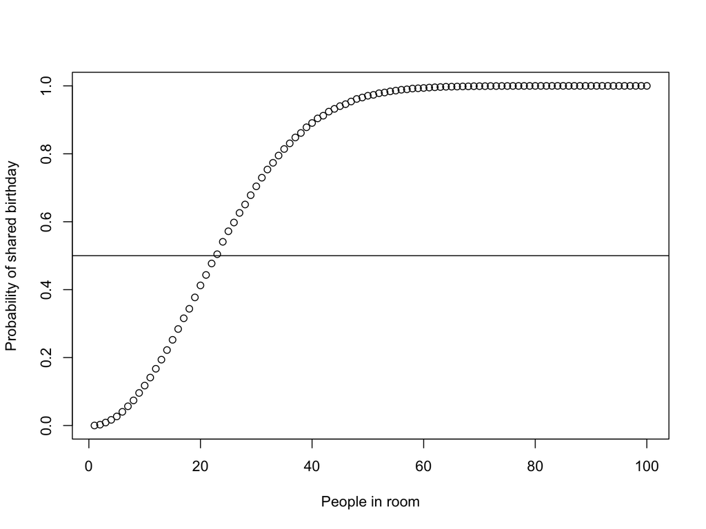

```r
plot(bdayp, xlab="People in room", ylab="Probability of shared birthday")
abline(h=0.5)
```

## Executing foreach in parallel on your machine

- To register `doParallel` to be used with `foreach`, you must call the `registerDoParallel` function.
- This register’s a parallel backend for `foreach` that is the cores of your machine.
- Let’s make our cluster:

```r
cl <- makeCluster(2)
registerDoParallel(cl)
getDoParWorkers() # Check that the nodes are running
```

```
## [1] 2
```

We run exactly the same thing as before, but now we change `%do%` to `%dopar%`:

```r
ptime <- system.time({
  bdayp <- foreach(n = 1:100, .combine = 'c') %dopar% pbirthdaysim(n)
})

ptime
```

```
##    user  system elapsed
##   0.082   0.007 165.644
```

```r
stopCluster(cl)
```

## Executing foreach in parallel on Azure

Dependencies:

```r
# install the package devtools
#install.packages("devtools")

# install the doAzureParallel and rAzureBatch package
#devtools::install_github("Azure/rAzureBatch")
#devtools::install_github("Azure/doAzureParallel")

library(doAzureParallel)
```

## Set up for Azure

- Step 1: Get an [Azure account](https://azure.microsoft.com/en-gb/free/search/?&OCID=AID719823_SEM_ZesfCvwc&lnkd=Google_Azure_Brand&dclid=CIPA5fnokOICFbIh0wodriICmg).
- Step 2: Create a **batch** account and a **storage** account. Do this using helpful prompts on [Azure](https://portal.azure.com/#home), or follow this [script](https://github.com/Azure/doAzureParallel/blob/master/docs/02-getting-started-script.md).
- Step 3: Set your credentials and cluster info and then we’re away to go!

## Credentials file

You can auto-generate these and fill them in with the correct information.

```r
generateCredentialsConfig("credentials.json")
```

```bash
cat credentials.json
```

```
{
  "sharedKey": {
    "batchAccount": {
      "name": "batch_account_name",
      "key": "batch_account_key",
      "url": "batch_account_url"
    },
    "storageAccount": {
      "name": "storage_account_name",
      "key": "storage_account_key",
      "endpointSuffix": "core.windows.net"
    }
  },
  "githubAuthenticationToken": "",
  "dockerAuthentication": {
    "username": "",
    "password": "",
    "registry": ""
  }
}
```

## Cluster file

Similarly…

```r
generateClusterConfig("cluster.json")
```

```bash
cat cluster.json
```

```
{
  "name": "myPoolName",
  "vmSize": "Standard_D2_v2",
  "maxTasksPerNode": 1,
  "poolSize": {
    "dedicatedNodes": {
      "min": 3,
      "max": 3
    },
    "lowPriorityNodes": {
      "min": 3,
      "max": 3
    },
    "autoscaleFormula": "QUEUE"
  },
  "containerImage": "rocker/tidyverse:latest",
  "rPackages": {
    "cran": [],
    "github": [],
    "bioconductor": []
  },
  "commandLine": [],
  "subnetId": ""
}
```

I’m going to change these default cluster options to look like:

```bash
cat my_cluster.json
```

```
{
  "name": "poola",
  "vmSize": "Standard_D2_v2",
  "maxTasksPerNode": 4,
  "poolSize": {
    "dedicatedNodes": {
      "min": 0,
      "max": 0
    },
    "lowPriorityNodes": {
      "min": 5,
      "max": 10
    },
    "autoscaleFormula": "QUEUE"
  },
  "containerImage": "rocker/tidyverse:3.5",
  "rPackages": {
    "cran": [],
    "github": [],
    "bioconductor": []
  },
  "commandLine": []
}
```

Set your credentials, then spin up your cluster - this will take a while the first time!

```r
setCredentials("my_credentials.json")
```

```
## ===========================================================================
## Batch Account: poulstonbatch
## Batch Account Url: https://poulstonbatch.uksouth.batch.azure.com
## Storage Account: poulstonstorage
## Storage Account Url: https://poulstonstorage.blob.core.windows.net
## ===========================================================================
## Your credentials have been successfully set.
```

```r
# Create your cluster if it does not exist; this takes a few minutes
cluster <- makeCluster("my_cluster.json")
```

```
## ===========================================================================
## Name: poola
## Configuration:
##  Docker Image: rocker/tidyverse:3.5
##  MaxTasksPerNode: 4
##  Node Size: Standard_D2_v2
## Scale:
##  Autoscale Formula: QUEUE
##  Dedicated:
##      Min: 0
##      Max: 0
##  Low Priority:
##      Min: 5
##      Max: 10
## ===========================================================================
## Booting compute nodes. . .
##
## Your cluster has been registered.
## Dedicated Node Count: 0
## Low Priority Node Count: 5
```

```r
# Register your parallel backend
registerDoAzureParallel(cluster)
# Check that the nodes are running
getDoParWorkers()
```

```
## [1] 20
```

Now that we’ve changed our parallel backend, let’s run the same thing again but on Azure.

```r
atime <- system.time({
  bdayp <- foreach(n = 1:100, .combine = 'c') %dopar% pbirthdaysim(n)
})
```

[output not shown]

[output cut: 64 more lines]

```
Submitting tasks (96/100)
Submitting tasks (97/100)
Submitting tasks (98/100)
Submitting tasks (99/100)
Submitting tasks (100/100)
## Submitting merge task. . .
## Waiting for tasks to complete. . .
##
| Progress: 0.00% (0/100) | Running: 16 | Queued: 69 | Completed: 0 | Failed: 0 |
| Progress: 16.00% (16/100) | Running: 20 | Queued: 64 | Completed: 16 | Failed: 0 |
| Progress: 38.00% (38/100) | Running: 20 | Queued: 42 | Completed: 38 | Failed: 0 |
| Progress: 58.00% (58/100) | Running: 20 | Queued: 22 | Completed: 58 | Failed: 0 |
| Progress: 78.00% (78/100) | Running: 20 | Queued: 2 | Completed: 78 | Failed: 0 |
| Progress: 100.00% (100/100) | Running: 0 | Queued: 0 | Completed: 100 | Failed: 0 |
## Tasks have completed. Merging results... Completed.
```

```r
atime
```

```
##    user  system elapsed
##   1.801   0.058  73.380
```

```r
stopCluster(cluster)
```

```
## [1] "Your poola cluster is being deleted."
```

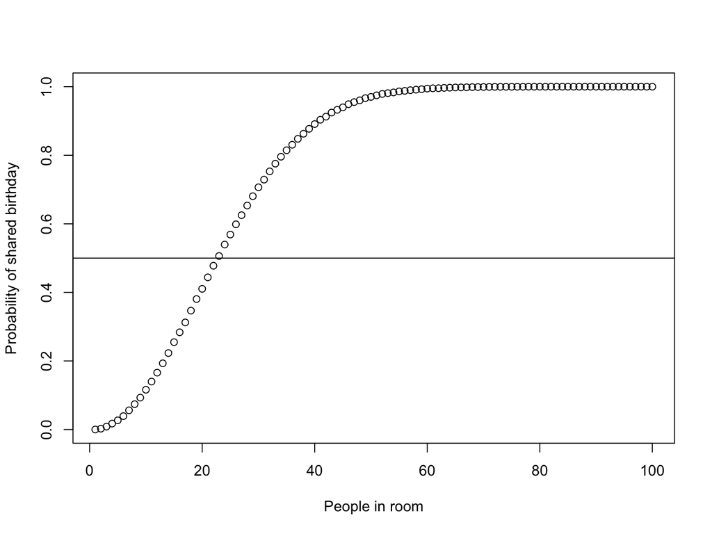

```r
plot(bdayp, xlab="People in room", ylab="Probability of shared birthday")
abline(h=0.5)
```